# Analysis of covariance (ANCOVA)

Przemyslaw Biecek

Linear models with fixed and random effects

# Contrasts

This is a copy of the last section of lecture `02_oneway`.

Consider a categorical variable with some number of levels.

```r
library(PBImisc)

head(vaccination)
```

```
##   response dose
## 1     88.9 0 ml
## 2    105.0 0 ml
## 3    138.4 0 ml
## 4     98.1 0 ml
## 5    107.2 0 ml
## 6     57.9 0 ml
```

```r
summary(vaccination)
```

```
##     response         dose
##  Min.   : 39.50   0 ml :20
##  1st Qu.: 77.30   10 ml:20
##  Median : 99.25   20 ml:20
##  Mean   : 97.89   30 ml:20
##  3rd Qu.:117.70   40 ml:20
##  Max.   :154.70
```

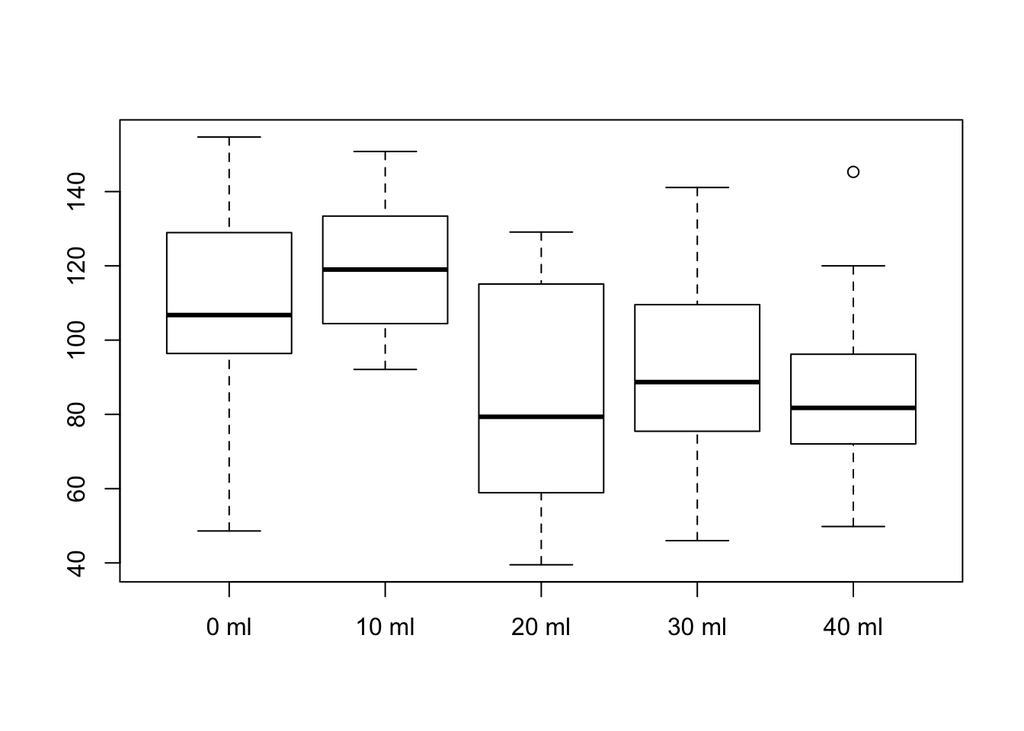

```r
boxplot(response ~ dose, data=vaccination)
```

## List of contrasts

We have to code the categorical variable somehow. And the coding is important.

```r
t(contr.treatment(5))
```

```
##   1 2 3 4 5
## 2 0 1 0 0 0
## 3 0 0 1 0 0
## 4 0 0 0 1 0
## 5 0 0 0 0 1
```

```r
t(contr.helmert(5))
```

```
##       1  2  3  4 5
## [1,] -1  1  0  0 0
## [2,] -1 -1  2  0 0
## [3,] -1 -1 -1  3 0
## [4,] -1 -1 -1 -1 4
```

```r
t(contr.poly(5))
```

```
##          [,1]       [,2]          [,3]       [,4]      [,5]
## .L -0.6324555 -0.3162278  0.000000e+00  0.3162278 0.6324555
## .Q  0.5345225 -0.2672612 -5.345225e-01 -0.2672612 0.5345225
## .C -0.3162278  0.6324555 -4.095972e-16 -0.6324555 0.3162278
## ^4  0.1195229 -0.4780914  7.171372e-01 -0.4780914 0.1195229
```

```r
t(contr.sdif(5))
```

```
##        1    2    3    4   5
## 2-1 -0.8  0.2  0.2  0.2 0.2
## 3-2 -0.6 -0.6  0.4  0.4 0.4
## 4-3 -0.4 -0.4 -0.4  0.6 0.6
## 5-4 -0.2 -0.2 -0.2 -0.2 0.8
```

```r
model.matrix(response~dose, vaccination)[1:5,]
```

```
##   (Intercept) dose10 ml dose20 ml dose30 ml dose40 ml
## 1           1         0         0         0         0
## 2           1         0         0         0         0
## 3           1         0         0         0         0
## 4           1         0         0         0         0
## 5           1         0         0         0         0
```

```r
model.matrix(response~dose, vaccination,
 contrasts=list(dose=contr.helmert))[1:5,]
```

```
##   (Intercept) dose1 dose2 dose3 dose4
## 1           1    -1    -1    -1    -1
## 2           1    -1    -1    -1    -1
## 3           1    -1    -1    -1    -1
## 4           1    -1    -1    -1    -1
## 5           1    -1    -1    -1    -1
```

```r
model.matrix(response~dose, vaccination,
 contrasts=list(dose=contr.poly))[1:5,]
```

```
##   (Intercept)     dose.L    dose.Q     dose.C    dose^4
## 1           1 -0.6324555 0.5345225 -0.3162278 0.1195229
## 2           1 -0.6324555 0.5345225 -0.3162278 0.1195229
## 3           1 -0.6324555 0.5345225 -0.3162278 0.1195229
## 4           1 -0.6324555 0.5345225 -0.3162278 0.1195229
## 5           1 -0.6324555 0.5345225 -0.3162278 0.1195229
```

## Contrasts in action

```r
summary(lm(response~dose, data = vaccination))
```

```
##
## Call:
## lm(formula = response ~ dose, data = vaccination)
##
## Residuals:
##    Min     1Q Median     3Q    Max
## -59.97 -14.53  -2.77  18.49  60.08
##
## Coefficients:
##             Estimate Std. Error t value Pr(>|t|)
## (Intercept)  108.570      5.485  19.794  < 2e-16 ***
## dose10 ml     10.695      7.757   1.379  0.17121
## dose20 ml    -24.545      7.757  -3.164  0.00209 **
## dose30 ml    -16.200      7.757  -2.088  0.03944 *
## dose40 ml    -23.350      7.757  -3.010  0.00334 **
## ---
## Signif. codes:  0 '***' 0.001 '**' 0.01 '*' 0.05 '.' 0.1 ' ' 1
##
## Residual standard error: 24.53 on 95 degrees of freedom
## Multiple R-squared:  0.2503, Adjusted R-squared:  0.2187
## F-statistic: 7.929 on 4 and 95 DF,  p-value: 1.471e-05
```

```r
kontr = contr.sdif(5)
summary(lm(response ~ dose, data = vaccination, contrasts=list(dose=kontr)))
```

```
##
## Call:
## lm(formula = response ~ dose, data = vaccination, contrasts = list(dose = kontr))
##
## Residuals:
##    Min     1Q Median     3Q    Max
## -59.97 -14.53  -2.77  18.49  60.08
##
## Coefficients:
##             Estimate Std. Error t value Pr(>|t|)
## (Intercept)   97.890      2.453  39.906  < 2e-16 ***
## dose2-1       10.695      7.757   1.379    0.171
## dose3-2      -35.240      7.757  -4.543 1.63e-05 ***
## dose4-3        8.345      7.757   1.076    0.285
## dose5-4       -7.150      7.757  -0.922    0.359
## ---
## Signif. codes:  0 '***' 0.001 '**' 0.01 '*' 0.05 '.' 0.1 ' ' 1
##
## Residual standard error: 24.53 on 95 degrees of freedom
## Multiple R-squared:  0.2503, Adjusted R-squared:  0.2187
## F-statistic: 7.929 on 4 and 95 DF,  p-value: 1.471e-05
```

```r
model.va.7 <- lm(response~ordered(dose), data=vaccination)
summary(model.va.7)
```

```
##
## Call:
## lm(formula = response ~ ordered(dose), data = vaccination)
##
## Residuals:
##    Min     1Q Median     3Q    Max
## -59.97 -14.53  -2.77  18.49  60.08
##
## Coefficients:
##                 Estimate Std. Error t value Pr(>|t|)
## (Intercept)       97.890      2.453  39.906  < 2e-16 ***
## ordered(dose).L  -23.273      5.485  -4.243 5.13e-05 ***
## ordered(dose).Q    2.110      5.485   0.385  0.70133
## ordered(dose).C    9.626      5.485   1.755  0.08249 .
## ordered(dose)^4  -17.761      5.485  -3.238  0.00166 **
## ---
## Signif. codes:  0 '***' 0.001 '**' 0.01 '*' 0.05 '.' 0.1 ' ' 1
##
## Residual standard error: 24.53 on 95 degrees of freedom
## Multiple R-squared:  0.2503, Adjusted R-squared:  0.2187
## F-statistic: 7.929 on 4 and 95 DF,  p-value: 1.471e-05
```

## Compare all contrasts

```r
options()$contrasts
```

```
##         unordered           ordered
## "contr.treatment"      "contr.poly"
```

```r
contrs <- apropos("contr\\.")
coefs <- sapply(contrs, function(i)
 lm(response~dose, data = vaccination,
 contrasts=list(dose=get(i)))$coefficients
)
t(coefs)
```

```
##                 (Intercept)     dose1      dose2      dose3    dose4
## contr.helmert         97.89   5.34750  -9.964167  -2.895833  -3.1675
## contr.poly            97.89 -23.27278   2.110028   9.625973 -17.7611
## contr.SAS             85.22  23.35000  34.045000  -1.195000   7.1500
## contr.sdif            97.89  10.69500 -35.240000   8.345000  -7.1500
## contr.sum             97.89  10.68000  21.375000 -13.865000  -5.5200
## contr.treatment      108.57  10.69500 -24.545000 -16.200000 -23.3500
```

## Your turn

In small groups, 2-3 people each, find an example application for each type of contrast.

# Order of tests

Let us consider a simple model with two variables `X` and `Z`. Note that they are correlated and both have some relation with variable `Y`.

```r
library(PBImisc)
head(YXZ)
```

```
##           Y          X          Z
## 1 -3.295356  0.7306656  0.5782933
## 2 -1.537665  3.0913065  4.6250460
## 3 11.399181  2.5076602  2.9728490
## 4  3.181729  1.6866157  3.2181538
## 5 -7.517721 -0.6143104 -0.7614809
## 6  2.601908  4.1498046  5.5484810
```

```r
cor(YXZ)
```

```
##           Y         X         Z
## Y 1.0000000 0.2447155 0.2646026
## X 0.2447155 1.0000000 0.7764879
## Z 0.2646026 0.7764879 1.0000000
```

## What we are testing?

There is a lot of approaches to test the relation between X/Z and Y. Let’s check them.

```r
# this is quite often
# type III - marginal
summary(lm(Y~X+Z, data=YXZ))
```

```
##
## Call:
## lm(formula = Y ~ X + Z, data = YXZ)
##
## Residuals:
##     Min      1Q  Median      3Q     Max
## -11.351  -4.120   0.134   3.885  14.818
##
## Coefficients:
##             Estimate Std. Error t value Pr(>|t|)
## (Intercept)  -0.2016     0.5511  -0.366    0.715
## X             0.3013     0.4725   0.638    0.525
## Z             0.4462     0.3683   1.211    0.229
##
## Residual standard error: 5.422 on 97 degrees of freedom
## Multiple R-squared:  0.0739, Adjusted R-squared:  0.0548
## F-statistic:  3.87 on 2 and 97 DF,  p-value: 0.02416
```

```r
# is it a surprise?
# type I - sequential
anova(lm(Y~X+Z, data=YXZ))
```

```
## Analysis of Variance Table
##
## Response: Y
##           Df  Sum Sq Mean Sq F value  Pr(>F)
## X          1  184.37 184.372  6.2724 0.01393 *
## Z          1   43.13  43.132  1.4674 0.22870
## Residuals 97 2851.23  29.394
## ---
## Signif. codes:  0 '***' 0.001 '**' 0.01 '*' 0.05 '.' 0.1 ' ' 1
```

```r
anova(lm(Y~Z+X, data=YXZ))
```

```
## Analysis of Variance Table
##
## Response: Y
##           Df  Sum Sq Mean Sq F value   Pr(>F)
## Z          1  215.56 215.556  7.3333 0.008001 **
## X          1   11.95  11.948  0.4065 0.525266
## Residuals 97 2851.23  29.394
## ---
## Signif. codes:  0 '***' 0.001 '**' 0.01 '*' 0.05 '.' 0.1 ' ' 1
```

```r
# What about this?
anova(lm(Y~X, data=YXZ))
```

```
## Analysis of Variance Table
##
## Response: Y
##           Df  Sum Sq Mean Sq F value  Pr(>F)
## X          1  184.37 184.372  6.2426 0.01413 *
## Residuals 98 2894.36  29.534
## ---
## Signif. codes:  0 '***' 0.001 '**' 0.01 '*' 0.05 '.' 0.1 ' ' 1
```

```r
anova(lm(Y~Z, data=YXZ))
```

```
## Analysis of Variance Table
##
## Response: Y
##           Df  Sum Sq Mean Sq F value   Pr(>F)
## Z          1  215.56 215.556   7.378 0.007806 **
## Residuals 98 2863.17  29.216
## ---
## Signif. codes:  0 '***' 0.001 '**' 0.01 '*' 0.05 '.' 0.1 ' ' 1
```

## Your turn

In small groups, 2-3 people each, explain what has happen. Why this has happened?

Find example in which one would like to use type I test. And when type III test would be more useful?

# Nested or crossed?

Let’s play with data about prices of apartments in Warsaw.

```r
library(PBImisc)
head(apartments)
```

```
##   year month surface     city    district     street n.rooms floor
## 1 2008     1      20 Warszawa Srodmiescie      Bagno       1     7
## 2 2008     1      25 Warszawa    Pruszkow   Pruszkow       1     1
## 3 2008     1      26 Warszawa     Bielany Marymoncka       1     6
## 4 2008     1      27 Warszawa        Wola     Sienna       1     1
## 5 2008     1      28 Warszawa     Mokotow Raclawicka       1     1
## 6 2008     1      28 Warszawa     Mokotow Miaczynska       2     4
##   construction.date         type offer.price transaction.price m2.price
## 1              1970   hipoteczne          NA            210000    10500
## 2              1965 spoldzielcze          NA            175000     7000
## 3              1964   hipoteczne          NA            218000     8384
## 4              1962 spoldzielcze          NA            230000     8518
## 5              1950   hipoteczne      250000            245000     8750
## 6              1968 spoldzielcze          NA            245000     8750
##    condition      lat      lon
## 1 do remontu 52.22947 21.00761
## 2 do remontu 52.17162 20.80639
## 3 do remontu 52.27114 20.95003
## 4      dobry 52.24238 20.98659
## 5 do remontu 52.19814 21.01752
## 6      dobry 52.19814 21.01752
```

Let’s select 7 variables that look like factors.

```r
head(apartments[,c(1,2,5,6,7,10,14)])
```

```
##   year month    district     street n.rooms         type  condition
## 1 2008     1 Srodmiescie      Bagno       1   hipoteczne do remontu
## 2 2008     1    Pruszkow   Pruszkow       1 spoldzielcze do remontu
## 3 2008     1     Bielany Marymoncka       1   hipoteczne do remontu
## 4 2008     1        Wola     Sienna       1 spoldzielcze      dobry
## 5 2008     1     Mokotow Raclawicka       1   hipoteczne do remontu
## 6 2008     1     Mokotow Miaczynska       2 spoldzielcze      dobry
```

## Your turn

In small groups, 2-3 peoples each, choose how to code each variable. What kind of contrast should / might be used?

For pairs of variables like type/condition, district/street, year/month, discuss if they should be coded as nested or crossed variables?

## Try with R

What will be the difference between

```r
model1 <- lm(m2.price ~ factor(year)+factor(month), data=apartments)

model2 <- lm(m2.price ~ factor(year)/factor(month), data=apartments)

model3 <- lm(m2.price ~ factor(year)*factor(month), data=apartments)

summary(model1)
```

```
##
## Call:
## lm(formula = m2.price ~ factor(year) + factor(month), data = apartments)
##
## Residuals:
##     Min      1Q  Median      3Q     Max
## -5258.4 -1403.0  -385.3   988.2 12530.8
##
## Coefficients:
##                  Estimate Std. Error t value Pr(>|t|)
## (Intercept)       9311.75     325.01  28.651  < 2e-16 ***
## factor(year)2008  -236.04     212.36  -1.112  0.26663
## factor(year)2009  -914.94     252.75  -3.620  0.00031 ***
## factor(month)2    -359.67     350.98  -1.025  0.30574
## factor(month)3    -168.98     331.24  -0.510  0.61007
## factor(month)4     -37.81     341.04  -0.111  0.91174
## factor(month)5    -369.02     325.63  -1.133  0.25739
## factor(month)6    -237.55     317.06  -0.749  0.45391
## factor(month)7    -131.01     331.36  -0.395  0.69267
## factor(month)8    -183.25     354.95  -0.516  0.60579
## factor(month)9    -134.27     331.29  -0.405  0.68535
## factor(month)10   -299.78     377.28  -0.795  0.42705
## factor(month)11   -346.50     504.84  -0.686  0.49265
## factor(month)12   -497.46     358.78  -1.387  0.16591
## ---
## Signif. codes:  0 '***' 0.001 '**' 0.01 '*' 0.05 '.' 0.1 ' ' 1
##
## Residual standard error: 2044 on 959 degrees of freedom
## Multiple R-squared:  0.02724,    Adjusted R-squared:  0.01406
## F-statistic: 2.066 on 13 and 959 DF,  p-value: 0.01393
```

```r
summary(model2)
```

```
##
## Call:
## lm(formula = m2.price ~ factor(year)/factor(month), data = apartments)
##
## Residuals:
##     Min      1Q  Median      3Q     Max
## -5258.4 -1340.4  -367.7   997.1 12621.8
##
## Coefficients: (12 not defined because of singularities)
##                                  Estimate Std. Error t value Pr(>|t|)
## (Intercept)                       8740.46     299.98  29.137   <2e-16 ***
## factor(year)2008                   189.31     434.21   0.436   0.6630
## factor(year)2009                  -116.60     493.25  -0.236   0.8132
## factor(year)2007:factor(month)2        NA         NA      NA       NA
## factor(year)2008:factor(month)2    133.00     432.00   0.308   0.7582
## factor(year)2009:factor(month)2  -1401.50     600.23  -2.335   0.0198 *
## factor(year)2007:factor(month)3        NA         NA      NA       NA
## factor(year)2008:factor(month)3   -132.02     423.93  -0.311   0.7556
## factor(year)2009:factor(month)3   -232.53     524.46  -0.443   0.6576
## factor(year)2007:factor(month)4        NA         NA      NA       NA
## factor(year)2008:factor(month)4   -250.09     441.38  -0.567   0.5711
## factor(year)2009:factor(month)4    216.52     531.66   0.407   0.6839
## factor(year)2007:factor(month)5        NA         NA      NA       NA
## factor(year)2008:factor(month)5   -311.82     422.09  -0.739   0.4602
## factor(year)2009:factor(month)5   -480.68     506.75  -0.949   0.3431
## factor(year)2007:factor(month)6    242.78     401.69   0.604   0.5457
## factor(year)2008:factor(month)6    324.12     420.31   0.771   0.4408
## factor(year)2009:factor(month)6  -1193.16     577.30  -2.067   0.0390 *
## factor(year)2007:factor(month)7    615.98     409.98   1.502   0.1333
## factor(year)2008:factor(month)7     55.32     455.51   0.121   0.9034
## factor(year)2009:factor(month)7   -960.57     619.09  -1.552   0.1211
## factor(year)2007:factor(month)8        NA         NA      NA       NA
## factor(year)2008:factor(month)8   -754.41     584.85  -1.290   0.1974
## factor(year)2009:factor(month)8   -171.24     484.22  -0.354   0.7237
## factor(year)2007:factor(month)9        NA         NA      NA       NA
## factor(year)2008:factor(month)9     11.68     377.61   0.031   0.9753
## factor(year)2009:factor(month)9        NA         NA      NA       NA
## factor(year)2007:factor(month)10   258.46     417.69   0.619   0.5362
## factor(year)2008:factor(month)10  -124.76     535.45  -0.233   0.8158
## factor(year)2009:factor(month)10       NA         NA      NA       NA
## factor(year)2007:factor(month)11   224.79     487.67   0.461   0.6449
## factor(year)2008:factor(month)11       NA         NA      NA       NA
## factor(year)2009:factor(month)11       NA         NA      NA       NA
## factor(year)2007:factor(month)12       NA         NA      NA       NA
## factor(year)2008:factor(month)12  -254.48     465.64  -0.547   0.5848
## factor(year)2009:factor(month)12       NA         NA      NA       NA
## ---
## Signif. codes:  0 '***' 0.001 '**' 0.01 '*' 0.05 '.' 0.1 ' ' 1
##
## Residual standard error: 2035 on 949 degrees of freedom
## Multiple R-squared:  0.04641,    Adjusted R-squared:  0.0233
## F-statistic: 2.008 on 23 and 949 DF,  p-value: 0.00336
```

```r
summary(model3)
```

```
##
## Call:
## lm(formula = m2.price ~ factor(year) * factor(month), data = apartments)
##
## Residuals:
##     Min      1Q  Median      3Q     Max
## -5258.4 -1340.4  -367.7   997.1 12621.8
##
## Coefficients: (12 not defined because of singularities)
##                                   Estimate Std. Error t value Pr(>|t|)
## (Intercept)                       8994.933    553.903  16.239   <2e-16 ***
## factor(year)2008                   -65.171    456.347  -0.143   0.8865
## factor(year)2009                  -371.081    678.319  -0.547   0.5845
## factor(month)2                   -1401.502    600.230  -2.335   0.0198 *
## factor(month)3                    -232.528    524.456  -0.443   0.6576
## factor(month)4                     216.523    531.661   0.407   0.6839
## factor(month)5                    -480.677    506.747  -0.949   0.3431
## factor(month)6                     -11.691    614.960  -0.019   0.9848
## factor(month)7                     361.501    620.410   0.583   0.5602
## factor(month)8                    -171.244    484.224  -0.354   0.7237
## factor(month)9                      11.685    377.613   0.031   0.9753
## factor(month)10                      3.986    625.527   0.006   0.9949
## factor(month)11                    -29.683    674.271  -0.044   0.9649
## factor(month)12                   -254.476    465.642  -0.547   0.5848
## factor(year)2008:factor(month)2   1534.506    739.529   2.075   0.0383 *
## factor(year)2009:factor(month)2         NA         NA      NA       NA
## factor(year)2008:factor(month)3    100.512    674.369   0.149   0.8815
## factor(year)2009:factor(month)3         NA         NA      NA       NA
## factor(year)2008:factor(month)4   -466.611    691.001  -0.675   0.4997
## factor(year)2009:factor(month)4         NA         NA      NA       NA
## factor(year)2008:factor(month)5    168.857    659.508   0.256   0.7980
## factor(year)2009:factor(month)5         NA         NA      NA       NA
## factor(year)2008:factor(month)6    335.816    598.098   0.561   0.5746
## factor(year)2009:factor(month)6  -1181.465    843.479  -1.401   0.1616
## factor(year)2008:factor(month)7   -306.184    628.716  -0.487   0.6264
## factor(year)2009:factor(month)7  -1322.075    876.460  -1.508   0.1318
## factor(year)2008:factor(month)8   -583.165    759.288  -0.768   0.4427
## factor(year)2009:factor(month)8         NA         NA      NA       NA
## factor(year)2008:factor(month)9         NA         NA      NA       NA
## factor(year)2009:factor(month)9         NA         NA      NA       NA
## factor(year)2008:factor(month)10  -128.748    693.456  -0.186   0.8528
## factor(year)2009:factor(month)10        NA         NA      NA       NA
## factor(year)2008:factor(month)11        NA         NA      NA       NA
## factor(year)2009:factor(month)11        NA         NA      NA       NA
## factor(year)2008:factor(month)12        NA         NA      NA       NA
## factor(year)2009:factor(month)12        NA         NA      NA       NA
## ---
## Signif. codes:  0 '***' 0.001 '**' 0.01 '*' 0.05 '.' 0.1 ' ' 1
##
## Residual standard error: 2035 on 949 degrees of freedom
## Multiple R-squared:  0.04641,    Adjusted R-squared:  0.0233
## F-statistic: 2.008 on 23 and 949 DF,  p-value: 0.00336
```

```r
# What about: type/condition, district/street
```

# Home works

Let’s see home works `agnieszka_sitko_05.html`, `hw5_emilia_pompe.html`, `Katarzyna_Kanska_h5.Rmd`.

https://rawgit.com/kgajewska/LinearModels/c9db0bc8cdd4cdd3c5187ee8ebea680a17292670/MIMUW_2015/HomeWorks/Fifth/karolina_gajewska_h5.html

## Home work for 12 XI 2015

Read the chapter 2.5 from ,,Analiza danych z programem R, Modele liniowe mieszane’’ or in English (http://www.statisticshell.com/docs/ancova.pdf + how to do this in R http://www.stat.columbia.edu/~martin/W2024/R8.pdf).

Now consider scenario with ,,unequal slopes’’ - an interaction between continuous and categorical variable. We are going to check when such interaction can be detected.

Create following scenarios:

Generate continuous variable `X_1` from distribution `U[0,1]`. Generate categorical variable `X_2` with 2 levels with equal frequency). Generate Y in a way that it depends on interaction of `X_1` and `X_2`.

1. Add random noise from N(0,1), all ANCOVA assumptions are met.
2. Choose other distribution for epsilons, find a distribution with the same scale as N(0,1) for which you will get drop in power.
3. Choose other distribution for epsilons in a way that the test for residual will not keep I type error rate.

For all these scenarios, produce plot that will compare power as a function of sample size. Moreover on this plot is should be visible that power for scenario 2 is lower than for scenario 1. And that I type error rate is different for scenario 3 and scenario 1.